# Jing Qiang Goh

## Summary of Data (Part 2)

Get basic ideas on the outliers/average of your data!

June 15, 2018

# Summary of Data (Part 2)

This post suggests the revised functionalites offered by the `summary` function described previously in the [Summary of Data](https://jqgoh.github.io/summary-of-data.html). The functions are mainly available at the preprocess.py file. We use a simple set of data 'beijing_201802_201803_aq.csv' from [KDD CUP of Fresh Air](https://biendata.com/competition/kdd_2018/), which provides air qualities measured by the weather stations in Beijing during February, March 2018.

The following mainly presents two functionalities:

1. **warn_missing** - Describe the proportion of missing values
2. **summary** - Provide the descriptive summary of data distribution. The visualization of data distribution can exclude outliers (*filter_outlier=True*) specified by a set of quantiles.

To test the execution of functions, plese clone the repository jqlearning and work on the jupyter notebook: Summary-of-data2.ipynb.

```python
# Import functions and load data into a dataframe
import sys
sys.path.append("../")
import pandas as pd
from script.preprocess import summary, warn_missing

kwargs = {"parse_dates": ["utc_time"]}
bj_aq_df = pd.read_csv("beijing_201802_201803_aq.csv", **kwargs)
```

```python
warn_missing(bj_aq_df, "beijing_201802_201803_aq.csv")
```

[output not shown]

The following summary considers the top 1% and bottom 1% of given numeric data as outliers. `summary` function offers us a simple idea on the type of data and the numeric data distribution.

```
--------------------------------------------------------------------------------
********************    Begin of the summary of text data   ********************
--------------------------------------------------------------------------------
count          49420
unique            35
top       tiantan_aq
freq            1412
Name: stationId, dtype: object


count                   49420
unique                   1412
top       2018-02-23 16:00:00
freq                       35
first     2018-01-31 16:00:00
last      2018-03-31 15:00:00
Name: utc_time, dtype: object


--------------------------------------------------------------------------------
********************    End of the summary of text data     ********************
--------------------------------------------------------------------------------
```

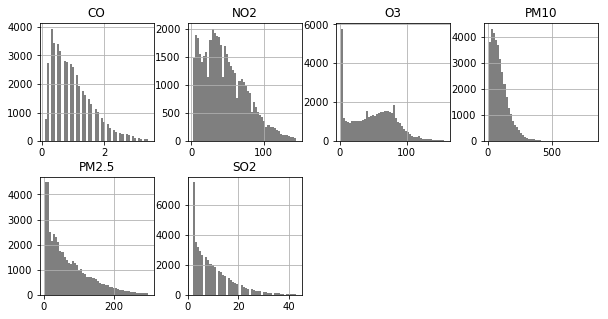

```python
summary(bj_aq_df, quantile=(0.01, 0.99), outlier_as_nan=True, filter_outlier=True)
```

User can also set *outlier_as_nan=False* parameter to display the outliers of data. This setting basically set the non-outliers as NaN (not a number). This offers us the convenience to understand the bigger picture of our available data before we proceed further to uncover additional insights!

```
--------------------------------------------------------------------------------
********************    Begin of the summary of text data   ********************
--------------------------------------------------------------------------------
count          49420
unique            35
top       tiantan_aq
freq            1412
Name: stationId, dtype: object


count                   49420
unique                   1412
top       2018-02-23 16:00:00
freq                       35
first     2018-01-31 16:00:00
last      2018-03-31 15:00:00
Name: utc_time, dtype: object


--------------------------------------------------------------------------------
********************    End of the summary of text data     ********************
--------------------------------------------------------------------------------
```

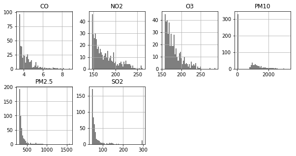

```python
summary(bj_aq_df, quantile=(0.01, 0.99), outlier_as_nan=False, filter_outlier=True)
```

- Email
- [GitHub](https://github.com/JQGoh)
- [LinkedIn](https://sg.linkedin.com/in/jingqianggoh)
- [Twitter](https://twitter.com/JQGoh)

© Jing Qiang Goh. Design credited to: [HTML5 UP](http://html5up.net).